# H8: A Gateway to Understanding Household Privacy and Financial Disparities

- Show All Code
- Hide All Code
- View Source

Author

Prashant Upadhyay

Published

November 15, 2023

## Introduction

In this census data analysis, the exploration of household dynamics goes beyond just statistics, unraveling issues hidden behind closed doors. This investigation focuses on a pivotal variable, `H8`, which delves into the privacy arrangements within households. `H8`, a binary signal reflecting whether all rooms are exclusively accessible to the household, becomes a gateway to understanding the intricate correlation between household privacy and financial hurdles.

The hypothesis focuses on the interesting correlation between `H8` responses and the average household income, particularly among individuals identifying as Asian. The initial premise shows that households with `H8` equal to `1`, indicative of shared room accessibility, could be associated with lower average incomes within the Asian Ethnicity of the dataset. The Exploration begins with loading data, filtering continuous variables, and finding correlations, leading to an examination of the `H8` variable and its connection to household incomes.

Through visualizations, the aim is to uncover patterns that shed light on the relationships between ethnicity, privacy preferences, and socioeconomic status. The subsequent sections consist of the Correlation Matrix, Uni-variate Analysis of `H8`, subsetting data for deeper insights, and the verification of our hypothesis by comparing average household incomes. The findings promise a deeper understanding of how privacy choices within households may be linked to broader financial dynamics, unravelling the societal intricacies that resonate beyond the numbers.

```r
# Loading the required packages
library(tidyverse)
library(PerformanceAnalytics)
library(ggridges)
library(downlit)
```

## Loading Data & Filtering it

After loading packages, the data is loaded and some filtering is done to the data so that we can focus on Continuous variables and check if we can find some correlation in their behavior.

```r
#Reading the data and creating a new tibble for continuous variables
UK_census <- read.csv("D:/Prashant Uni/Data Science/data-1.csv")
Continuous_data<-UK_census|>
  relocate(Mar_Stat,.after = H8)|>
    relocate(Person_ID, .after = H8)
Continuous_data <- Continuous_data[1:5]
```

## Exploratory Data Analysis

### Correlation Matrix

Once the Continuous data is filtered out, the next step is to find any correlation between them using the Performance Matrix . The below Figure 1 displays the correlation along with some new information to provide a direction to this procedure. A conclusion can be drawn with the help of Figure 1, that there is a correlation between `H8` and `INC` columns of the data.(Peterson and Carl 2020)

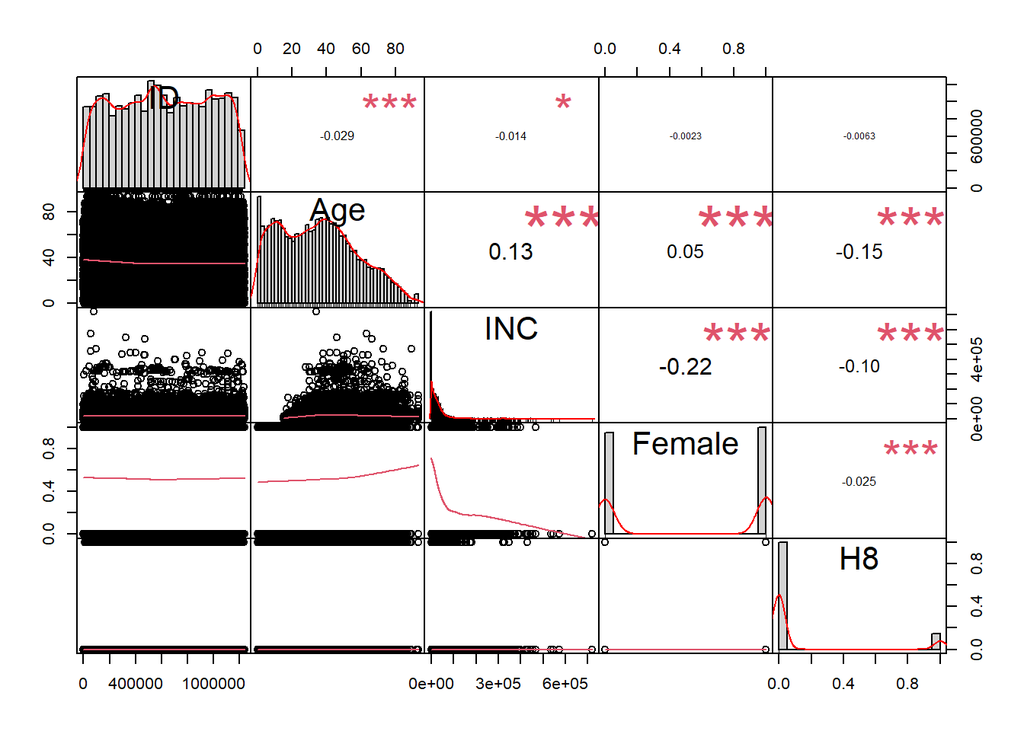

Figure 1: Correlation Matrix on Continuous Variables.

```r
#Plotting the correlation Matrix
chart.Correlation(Continuous_data, histogram = TRUE,pch=19)
```

### Uni-variate Analysis

After finding the correlations using the Figure 1 matrix,the next step is to analyse the `H8` variable in a more detailed fashion and check if there is any pattern that could be useful and explored a bit more using ggplot . In Figure 2 ,we plot a bar graph to see the variation in values of `H8` distributed over each ethnicity, using the correlation found in the Figure 1 Matrix.(Wickham 2016)

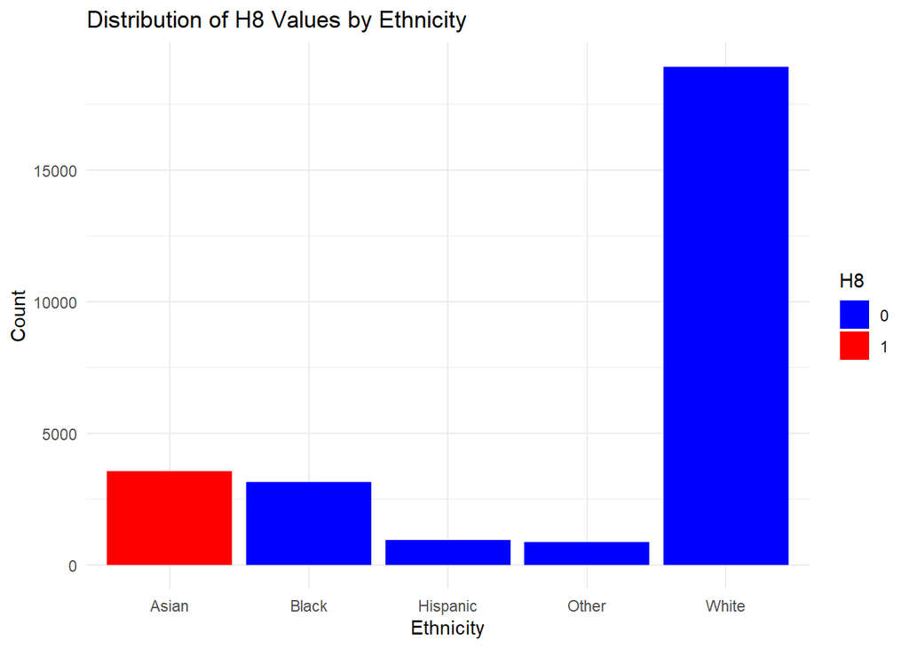

Figure 2: Barplot to assess the H8 variable in depth

```r
#Plotting a Bar graph for H8 variable.
ggplot(UK_census, aes(x = Eth, fill = factor(H8))) +
  geom_bar(position = "dodge", stat = "count") +
  labs(title = "Distribution of H8 Values by Ethnicity",
       x = "Ethnicity",
       y = "Count",
       fill = "H8") +
  scale_fill_manual(values = c("1" = "red", "0" = "blue")) +
  theme_minimal()
```

## Subsetting Data

After the Uni-variate Analysis, one conclusion can be drawn that `H8` is `1` only for Asian people and `0` for the other Ethnicities.To analyze this new information, Subsetting of the data is done so we can make some sense by using the information gained.In this process, a deeper analysis is done on whether the household income plays a role in this behaviour of the `H8` variable.(Peng et al. 2021)

```r
Household_INC_H8 <- UK_census|>
     filter(H8 == 0)|>
     group_by(ID)|>
     summarise(Household_INC = mean(INC, na.rm = TRUE))|>
     arrange(Household_INC)

Household_INC_nonH8 <- UK_census|>
     filter(H8 == 1)|>
     group_by(ID)|>
     summarise(Household_INC = mean(INC, na.rm = TRUE))|>
     arrange(Household_INC)
```

## Hypothesis Verification

In this section, a verification is done in Figure 3 on whether the `H8` being `1` for only Asian people is something related to their average household incomes. This is done by comparing the average household income of Asian people from Figure 3 (a) with the rest of the crowd from Figure 3 (b) by placing the average household income of Asian people and the rest of the crowd together in Figure 3.[Kartik, Nayyar, and Mitra (2018)][Wilke (2022)]

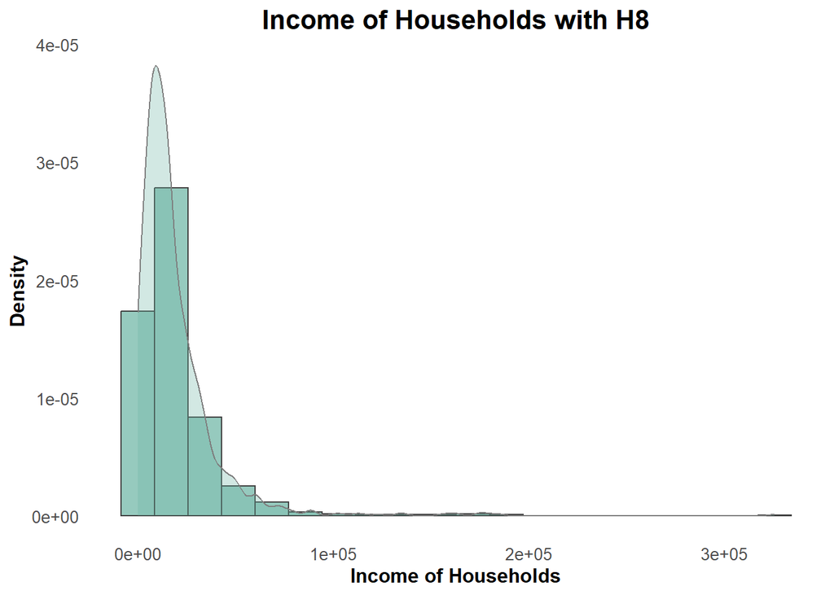

(a) The mean income of households with H8 is: 35843.21

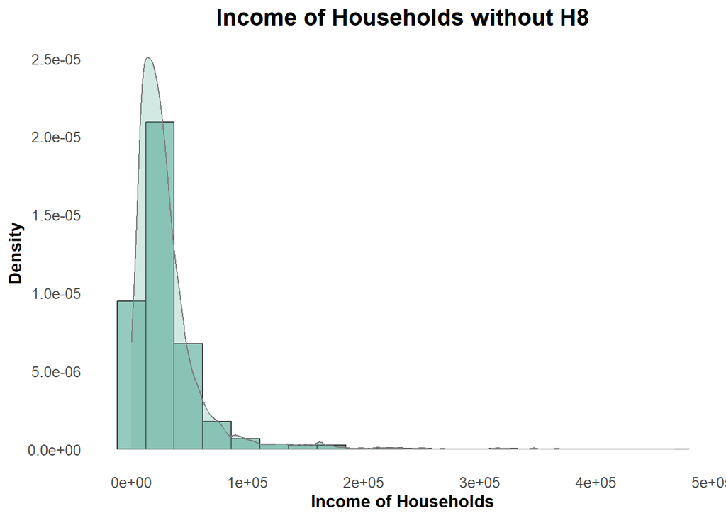

(b) The mean income of households without H8 is: 56308.17

Figure 3: Comparing the average incomes of Households with and without H8

```r
#Plotting the 2 graphs together for comparison

ggplot(Household_INC_nonH8, aes(x = Household_INC, y = stat(density))) +
  geom_histogram(bins = 20, fill = "#69b3a2", color = "#404040", alpha = 0.7) +
  geom_density(color = "#7e7e7e", fill = "#69b3a2", alpha = 0.3) +
  geom_vline(aes(xintercept = mean(Household_INC)), linetype = 2, color = "#e41a1c") +
  labs(title = "Income of Households with H8",
       x = "Income of Households",
       y = "Density") +
  theme_minimal() +
  theme(panel.grid = element_blank(),
        axis.text = element_text(size = 10),
        axis.title = element_text(size = 12, face = "bold"),
        plot.title = element_text(size = 16, face = "bold", hjust = 0.5),
        legend.position = "none")

ggplot(Household_INC_H8, aes(x = Household_INC, y = stat(density))) +
  geom_histogram(bins = 20, fill = "#69b3a2", color = "#404040", alpha = 0.7) +
  geom_density(color = "#7e7e7e", fill = "#69b3a2", alpha = 0.3) +
  geom_vline(aes(xintercept = mean(Household_INC)), linetype = 2, color = "#e41a1c") +
  labs(title = "Income of Households without H8",
       x = "Income of Households",
       y = "Density") +
  theme_minimal() +
  theme(panel.grid = element_blank(),
        axis.text = element_text(size = 10),
        axis.title = element_text(size = 12, face = "bold"),
        plot.title = element_text(size = 16, face = "bold", hjust = 0.5),
        legend.position = "none")
```

## Conclusion

The analysis of census data reveals a compelling connection between household privacy (`H8`) and financial disparities, notably among the Asian demographic. The Uni-variate Analysis underscores `H8`’s distribution, emphasizing its prevalence among Asians.

In essence, this exploration unveils an interesting interplay between household privacy choices and broader financial dynamics, particularly prominent in the dataset’s Asian population.

## References

Kartik, Dhruva, Ashutosh Nayyar, and Urbashi Mitra. 2018. “Sequential Experiment Design for Hypothesis Verification.” https://doi.org/10.48550/ARXIV.1812.01137.

Peng, Jinglin, Weiyuan Wu, Brandon Lockhart, Song Bian, Jing Nathan Yan, Linghao Xu, Zhixuan Chi, Jeffrey M. Rzeszotarski, and Jiannan Wang. 2021. “DataPrep.EDA: Task-Centric Exploratory Data Analysis for Statistical Modeling in Python.” *Proceedings of the 2021 International Conference on Management of Data*, June. https://doi.org/10.1145/3448016.3457330.

Peterson, Brian G., and Peter Carl. 2020. “PerformanceAnalytics: Econometric Tools for Performance and Risk Analysis.” https://CRAN.R-project.org/package=PerformanceAnalytics.

Wickham, Hadley. 2016. “Ggplot2: Elegant Graphics for Data Analysis.” https://ggplot2.tidyverse.org.

Wilke, Claus O. 2022. “Ggridges: Ridgeline Plots in ’Ggplot2’.” https://CRAN.R-project.org/package=ggridges.